# Solución de referencia: REGRESIÓN

Sesión 17 — ML + IA

Autor/a

Jorge Juvenal Campos Ferreira — TC2001B.601

Fecha de publicación

24 de mayo de 2026

*Problema: predecir el costo médico anual (en pesos) de un paciente. Modelo: KNN de regresión con el número de vecinos (k) tuneado por CV. Punto clave: la variable objetivo está SESGADA a la derecha; modelamos su logaritmo y luego exponenciamos para reportar en pesos.*

```r
options(scipen = 999)
```

```r
# Librerías (todas al inicio) ------------------------------------------------
library(tidyverse)
library(tidymodels)
library(kknn)            # motor para el modelo KNN
```

```r
tidymodels::tidymodels_prefer()
```

## 1. Cargar los datos

```r
# Removemos id_paciente: es un identificador, no un predictor; dejarlo podría
# inducir fuga de información (data leakage). La objetivo (costo_anual_mxn)
# se queda numérica: es un problema de regresión.
costos <- read_csv("datos.csv") %>%
  select(-id_paciente)
```

## 2. Explorar la variable objetivo: ¿está sesgada?

```r
# Comparamos media vs mediana: si la media es bastante mayor que la mediana,
# hay sesgo a la derecha (cola larga hacia costos altos). Eso es típico de
# variables monetarias y de conteo de uso de servicios.
costos %>%
  summarise(media = mean(costo_anual_mxn),
            mediana = median(costo_anual_mxn),
            minimo = min(costo_anual_mxn),
            maximo = max(costo_anual_mxn))
```

```
# A tibble: 1 × 4
   media mediana minimo maximo
   <dbl>   <dbl>  <dbl>  <dbl>
1 50086.  37860.   6676 317728
```

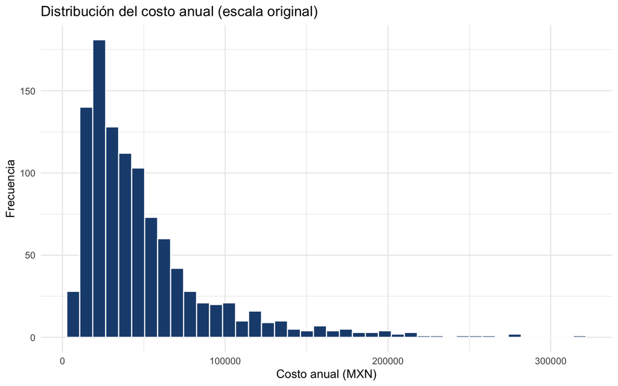

```r
# Histograma del costo en escala original: se ve la cola larga a la derecha.
costos %>%
  ggplot(aes(x = costo_anual_mxn)) +
  geom_histogram(bins = 40, fill = "#1e4c7d", color = "white") +
  labs(title = "Distribución del costo anual (escala original)",
       x = "Costo anual (MXN)", y = "Frecuencia") +
  theme_minimal()
```

## 3. ¿Por qué modelar log(costo_anual_mxn) y no el costo directo?

La objetivo está sesgada a la derecha (distribución tipo log-normal). Modelar el logaritmo del costo conviene porque:

1. ESTABILIZA LA VARIANZA: la dispersión del costo crece con su nivel (heterocedasticidad); el log la comprime y la vuelve más homogénea.
2. LINEALIZA RELACIONES: relaciones multiplicativas entre predictores y costo se vuelven aproximadamente lineales en escala log, lo que ayuda al modelo a ajustar mejor.
3. MEJORA EL AJUSTE: reduce el peso desproporcionado de los valores extremos, que de otro modo dominan el error cuadrático. Aplicamos la transformación DENTRO de la receta con step_log() sobre la objetivo. CONSECUENCIA: las métricas (RMSE, MAE) quedarán en escala logarítmica; para interpretarlas en pesos hay que EXPONENCIAR de vuelta (exp()) tanto la predicción como el valor real. Lo hacemos al final.

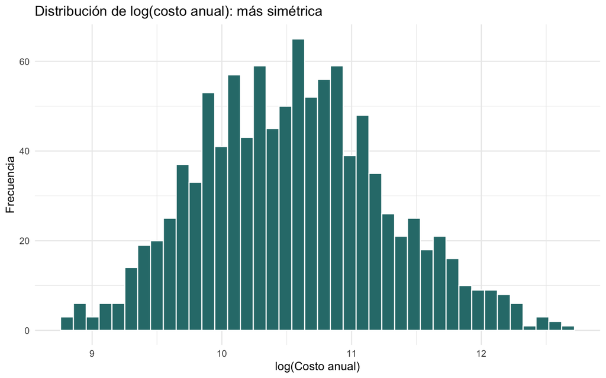

```r
# Histograma del log del costo: la distribución se ve mucho más simétrica.
costos %>%
  ggplot(aes(x = log(costo_anual_mxn))) +
  geom_histogram(bins = 40, fill = "#2d7a7a", color = "white") +
  labs(title = "Distribución de log(costo anual): más simétrica",
       x = "log(Costo anual)", y = "Frecuencia") +
  theme_minimal()
```

## 4. Revisar valores faltantes (NAs)

```r
# Esperamos ~42 NAs en imc (~4%). Los imputaremos en la receta.
summary(costos)
```

```
      edad           sexo                imc            hijos
 Min.   :18.00   Length:1050        Min.   :13.20   Min.   :0.00
 1st Qu.:31.00   Class :character   1st Qu.:24.30   1st Qu.:0.00
 Median :44.00   Mode  :character   Median :28.00   Median :1.00
 Mean   :43.85                      Mean   :27.95   Mean   :1.07
 3rd Qu.:56.75                      3rd Qu.:31.70   3rd Qu.:2.00
 Max.   :70.00                      Max.   :46.40   Max.   :7.00
                                    NA's   :42
   fumador             region          actividad_fisica_hrs_sem
 Length:1050        Length:1050        Min.   : 0.000
 Class :character   Class :character   1st Qu.: 1.700
 Mode  :character   Mode  :character   Median : 3.000
                                       Mean   : 3.037
                                       3rd Qu.: 4.300
                                       Max.   :10.000

 num_consultas_anio costo_anual_mxn
 Min.   :0.000      Min.   :  6676
 1st Qu.:1.000      1st Qu.: 22845
 Median :2.000      Median : 37860
 Mean   :2.523      Mean   : 50086
 3rd Qu.:4.000      3rd Qu.: 61469
 Max.   :9.000      Max.   :317728
```

## 5. Partición entrenamiento / prueba

```r
# En regresión podemos estratificar por la propia objetivo para que la
# distribución del costo quede parecida en ambas particiones.
set.seed(123)
costos_split <- initial_split(data = costos, prop = 0.75,
                              strata = costo_anual_mxn)
```

```r
costos_entrenamiento <- costos_split %>% training()
costos_prueba        <- costos_split %>% testing()
```

## 6. Receta de preprocesamiento (feature engineering)

```r
# El orden importa:
#   (1) step_log() sobre la objetivo: la transformamos PRIMERO. skip = FALSE
#       (valor por defecto) asegura que se aplique también al evaluar.
#   (2) step_impute_median(): imputa los NAs de imc antes de pasos que no
#       toleran NAs.
#   (3) step_unknown(): NAs categóricos -> nivel "unknown" antes de dummies.
#   (4) step_nzv(): quita predictores de varianza casi nula.
#   (5) step_normalize(): z-score sobre numéricos. INDISPENSABLE para KNN,
#       que se basa en distancias y es sensible a la escala.
#   (6) step_dummy(): codifica categóricas como variables binarias.
#   (7) step_zv(): elimina columnas dummy constantes.
receta_costos <- recipe(costo_anual_mxn ~ ., data = costos_entrenamiento) %>%
  step_log(costo_anual_mxn, base = exp(1)) %>%
  step_impute_median(all_numeric_predictors()) %>%
  step_unknown(all_nominal_predictors()) %>%
  step_nzv(all_predictors()) %>%
  step_normalize(all_numeric_predictors()) %>%
  step_dummy(all_nominal_predictors()) %>%
  step_zv(all_predictors())
```

## 7. Especificación del modelo KNN de regresión con k tuneable

```r
# Mismo modelo KNN, pero en modo "regression": en vez de votar una clase,
# promedia el valor (aquí, el log del costo) de los k vecinos más cercanos.
modelo_knn <- nearest_neighbor(neighbors = tune()) %>%
  set_engine("kknn") %>%
  set_mode("regression")
```

## 8. Workflow: receta + modelo

```r
workflow_knn <- workflow() %>%
  add_recipe(receta_costos) %>%
  add_model(modelo_knn)
```

## 9. Validación cruzada y tuning del hiperparámetro k

```r
# 5 folds sobre el entrenamiento. Nunca usamos la prueba para elegir k.
set.seed(123)
folds_cv <- vfold_cv(data = costos_entrenamiento, v = 5,
                     strata = costo_anual_mxn)
```

```r
# Grilla de valores candidatos de k.
grilla_k <- tibble(neighbors = c(3, 5, 7, 11, 15, 21, 31, 51, 75, 101))
```

```r
# Métricas de regresión. rmse es la principal; añadimos rsq y mae.
# OJO: estas métricas están en escala LOGARÍTMICA, porque el modelo predice
# el log del costo. Sirven para elegir k; el error en pesos lo calculamos
# después exponenciando.
metricas_tuning <- metric_set(rmse, rsq, mae)
```

```r
resultados_tuning <- workflow_knn %>%
  tune_grid(resamples = folds_cv,
            grid = grilla_k,
            metrics = metricas_tuning)
```

```r
# Métricas promediadas por valor de k (en escala log).
collect_metrics(resultados_tuning)
```

```
# A tibble: 30 × 7
   neighbors .metric .estimator  mean     n std_err .config
       <dbl> <chr>   <chr>      <dbl> <int>   <dbl> <chr>
 1         3 mae     standard   0.400     5  0.0136 pre0_mod01_post0
 2         3 rmse    standard   0.500     5  0.0207 pre0_mod01_post0
 3         3 rsq     standard   0.536     5  0.0307 pre0_mod01_post0
 4         5 mae     standard   0.370     5  0.0140 pre0_mod02_post0
 5         5 rmse    standard   0.467     5  0.0189 pre0_mod02_post0
 6         5 rsq     standard   0.583     5  0.0273 pre0_mod02_post0
 7         7 mae     standard   0.357     5  0.0142 pre0_mod03_post0
 8         7 rmse    standard   0.450     5  0.0180 pre0_mod03_post0
 9         7 rsq     standard   0.610     5  0.0259 pre0_mod03_post0
10        11 mae     standard   0.348     5  0.0129 pre0_mod04_post0
# ℹ 20 more rows
```

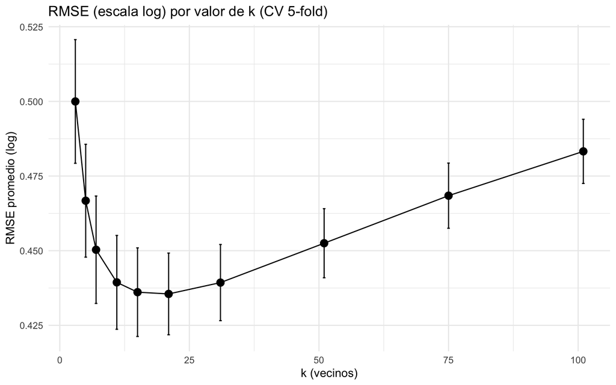

```r
# Visualizamos el RMSE (escala log) por k.
resultados_tuning %>%
  collect_metrics() %>%
  filter(.metric == "rmse") %>%
  ggplot(aes(x = neighbors, y = mean)) +
  geom_line() +
  geom_point(size = 3) +
  geom_errorbar(aes(ymin = mean - std_err, ymax = mean + std_err),
                width = 0.5) +
  labs(title = "RMSE (escala log) por valor de k (CV 5-fold)",
       x = "k (vecinos)",
       y = "RMSE promedio (log)") +
  theme_minimal()
```

## 10. Elegir el mejor k y finalizar el workflow

```r
# En regresión queremos el menor RMSE, así que select_best por rmse.
mejor_k <- resultados_tuning %>% select_best(metric = "rmse")
mejor_k
```

```
# A tibble: 1 × 2
  neighbors .config
      <dbl> <chr>
1        21 pre0_mod06_post0
```

```r
workflow_knn_final <- workflow_knn %>%
  finalize_workflow(mejor_k)
```

## 11. last_fit(): reentrena con todo el entrenamiento y evalúa en la prueba

```r
set.seed(123)
ajuste_final <- workflow_knn_final %>%
  last_fit(split = costos_split,
           metrics = metric_set(rmse, rsq, mae))
```

```r
# Métricas finales sobre la prueba EN ESCALA LOGARÍTMICA.
collect_metrics(ajuste_final)
```

```
# A tibble: 3 × 4
  .metric .estimator .estimate .config
  <chr>   <chr>          <dbl> <chr>
1 rmse    standard       0.416 pre0_mod0_post0
2 rsq     standard       0.673 pre0_mod0_post0
3 mae     standard       0.333 pre0_mod0_post0
```

## 12. Reportar el error EN PESOS (exponenciando de vuelta)

```r
# Las predicciones (.pred) y la objetivo de la receta están en log. Para
# interpretar el error en MXN, exponenciamos ambos y recalculamos las
# métricas en la escala original (pesos).
predicciones_finales <- collect_predictions(ajuste_final) %>%
  mutate(pred_pesos = exp(.pred),
         real_pesos = exp(costo_anual_mxn))
```

```r
# Métricas en pesos: ahora el RMSE y el MAE se leen directamente en MXN.
metricas_pesos <- metric_set(rmse, rsq, mae)
metricas_pesos(predicciones_finales, truth = real_pesos,
               estimate = pred_pesos)
```

```
# A tibble: 3 × 3
  .metric .estimator .estimate
  <chr>   <chr>          <dbl>
1 rmse    standard   27218.
2 rsq     standard       0.615
3 mae     standard   15961.
```

## 13. Gráfico de valores reales vs. predichos (en pesos)

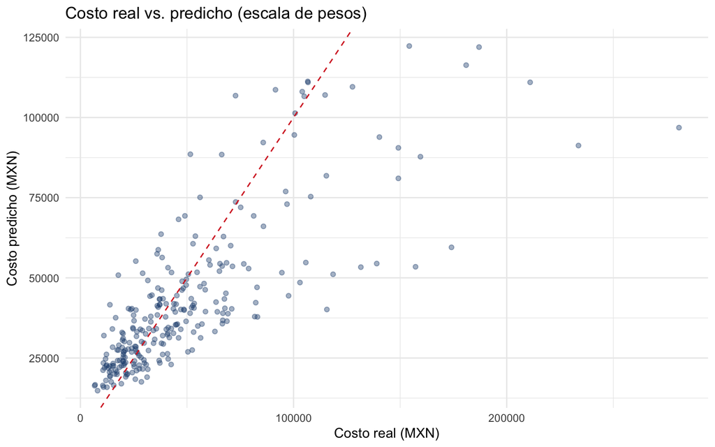

```r
# Una buena predicción cae cerca de la recta de 45 grados.
predicciones_finales %>%
  ggplot(aes(x = real_pesos, y = pred_pesos)) +
  geom_point(alpha = 0.4, color = "#1e4c7d") +
  geom_abline(slope = 1, intercept = 0, color = "#d62828",
              linetype = "dashed") +
  labs(title = "Costo real vs. predicho (escala de pesos)",
       x = "Costo real (MXN)", y = "Costo predicho (MXN)") +
  theme_minimal()
```

## Interpretación: — - El RSQ indica qué proporción de la variación del (log del) costo explica — el modelo; cerca de 1 es mejor. — - El RMSE en escala log sirve para elegir k; el RMSE en pesos es el que se — reporta al área de negocio porque está en la unidad que entienden (MXN). — - El k elegido por CV equilibra sesgo y varianza.